# PPOL 5203 Data Science I: Foundations Week 2: Practice Exercise Tiago Ventura </center>

## Practice Question 1

Consider the Python snippet below that simulates some data, runs a linear regression on the simulated data, and plots the predictors of the regression.

This is a poorly written code. It has the following issues:

- No comments documenting what the code is doing
- Poor redability
- Graphs with no meaning
- lines of code doing multiple things (you could split it up and make it more readable).

As an exercise, provide a refactored code as the solution to this problem.

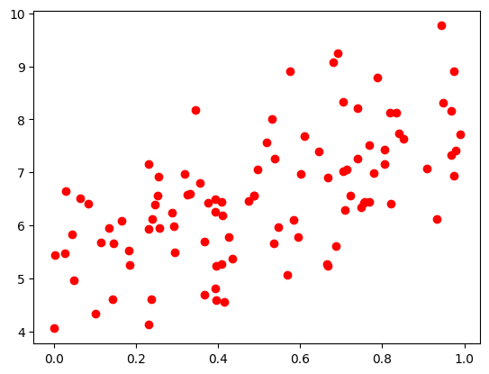

```python
import numpy as np
import matplotlib.pyplot as plt

a = np.random.rand(100)
b = 5 + 3*X1 + np.random.normal(size=100)
plt.scatter(a, b, color = 'red')
```

```python
# ADD YOUR RESPONSE HERE
```

## Practice Question 2

### Question 1: Initialize version control with git.

Create a folder called “Practice” on your desktop. Use the commandline to navigate to that folder. Next, initialize a git repository in that folder. Do all these steps using the commandline

```python
# ADD YOUR CODE (from Commandline) and Describe your steps HERE
```

### Question 2

Using the git repository that you created in Question 1. Do the following:

1. Create a `.txt` named `notes_about_ds5203` using either the commandline or just make this file yourself and move to the folder.
2. Add that file to the staging area.
3. Commit that file with a clear commit message
4. Create a repository on your own Github account
5. Create a remote version of your repo, and push your staged changes to a remote repo on github. To so do, you will need to do the following steps:
   - Create a repository on github.
     - Tip: create a empty directory
   - Link your local repository with the GitHub repository
     - Tip: follow the second code block provided by github after you create the empty
   - Push your local changes to github.

```python
# ADD YOUR CODE (from Commandline) and Describe your steps HERE
```